# Modul 1: Pengenalan R dan RStudio

#### Instalasi RStudio di macOS

2. Bukalah *file* yang telah di-*download*. Akan muncul tampilan seperti berikut.

[figure not shown]

3. Tarik aplikasi RStudio menuju *folder* Applications, seperti berikut, lalu lepas.

[figure not shown]

4. Tunggulah sebentar, karena aplikasi RStudio sedang dipasang di Mac yang sedang digunakan, degnan munculnya tampilan *loading* seperti berikut.

[figure not shown]

5. Apabila tampilan tersebut hilang, RStudio sudah selesai terpasang. Silakan buka *folder* “Applications”, kemudian *scroll* ke bawah hingga menemukan RStudio, untuk membuka RStudio.

[figure not shown]

6. Setelah membuka, akan ada tampilan *loading* seperti berikut. Harap ditunggu, boleh sambil melakukan hal lain.

[figure not shown]

7. Setelah *loading* selesai, akan muncul tampilan seperti ini, untuk memastikan bahwa RStudio–yang barusan di-*download* dari internet–ingin dibuka. Konfirmasikan dengan menekan “Open”.

[figure not shown]

8. RStudio akan terbuka dengan tampilan seperti berikut. Selamat menjalani praktikum!

[figure not shown]

## Menggunakan R di Google Colab

Bagi kalian yang ingin menggunakan R secara *online*, kalian ternyata bisa loh menggunakan Google Colaboratory. Kalian tinggal ikuti langkah berikut:

1. Kunjungi https://colab.research.google.com/ dan buat *notebook* baru.
2. Pilih *runtime* pada menu bagian atas.

[figure not shown]

3. Pilih *change runtime type* dan pilih R.

[figure not shown]

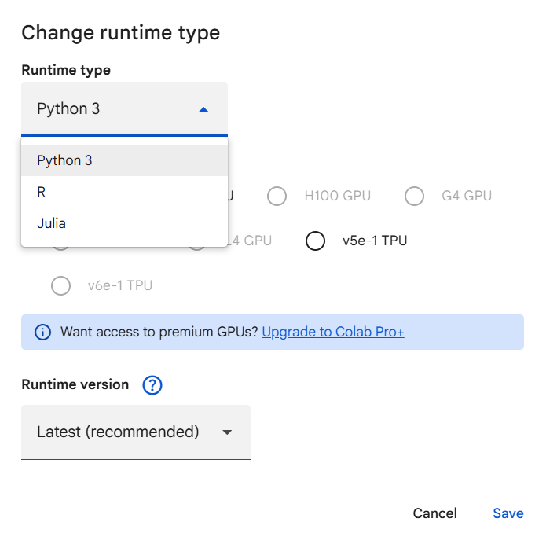

## Pengenalan R lebih detail

## Operasi Dasar

Layaknya bahasa pemrograman pada umumnya, R tentunya dapat melakukan operasi dasar.

**Cara Run Program**

Cara me-run sebaris program adalah dengan menekan `ctrl` + `Enter`

```r
2 + 3
```

```
[1] 5
```

```r
7 - 5
```

```
[1] 2
```

```r
3 * 5
```

```
[1] 15
```

```r
3 / 4
```

```
[1] 0.75
```

```r
2 ** 3
```

```
[1] 8
```

## Mendefinisikan Variabel di R

Pendefinisian variabel pada R dapat menggunakan tanda `<-` atau `=`

```r
jeruk <- 8
jeruk # sama seperti print(jeruk)
```

```
[1] 8
```

```r
apel = 5
print(apel)
```

```
[1] 5
```

Layaknya sebuah angka, variable tersebut dapat melakukan operasi dasar

```r
apel + jeruk
```

```
[1] 13
```

```r
apel - jeruk
```

```
[1] -3
```

```r
apel * jeruk
```

```
[1] 40
```

```r
apel / jeruk
```

```
[1] 0.625
```

Variabel juga dapat didefinisikan oleh variabel variabel lainnya

```r
banyakbuah <- jeruk + apel
banyakbuah
```

```
[1] 13
```

Variabel yang telah terdefinisi dapat dilihat pada environment (sebelah kanan script)

[figure not shown]

atau menggunakan syntax berikut

```r
ls()
```

```
[1] "apel"            "banyakbuah"      "jeruk"           "pandoc_dir"
[5] "quarto_bin_path"
```

untuk menghapus variabel, gunakan fungsi rm

```r
rm(banyakbuah)
```

untuk menghapus semua variabel gunakan

```r
rm(list = ls())
```

### Latihan

Coba jalankan perintah-perintah berikut di *console* RStudio Anda dan amati hasilnya:

1. Hitung luas lingkaran dengan jari-jari 7 menggunakan rumus $\pi r^2$. Buatlah variabel `r` untuk menyimpan nilai jari-jari dan `luas` untuk menyimpan hasilnya. (Gunakan `pi` untuk nilai $\pi$).
2. Tentukan apakah `(5 + 3) * 2` lebih besar dari `4^2`.

## Array dan Vektor

Jika sebelumnya kita berbicara operasi pada angka, kini kita akan menggunakan **array** dan **vektor**. Untuk mengingat kembali apa itu array, array adalah struktur data dalam pemrograman yang digunakan untuk menyimpan sekumpulan data dengan tipe data yang sama di dalam satu nama variabel.

Tentunya jenis data ini akan banyak kita gunakan nantinya, karena bermain dengan data.

```r
  # Vektor
  c(1, 2, 3, 4, 5, 6)
```

```
[1] 1 2 3 4 5 6
```

```r
# Array
  array(c(1, 2, 3, 4, 5, 6), dim = c(2, 3))
```

```
     [,1] [,2] [,3]
[1,]    1    3    5
[2,]    2    4    6
```

Sama seperti pada Python, operasi-operasi pada array tentunya bisa dilakukan dengan mudah tanpa harus membuat fungsi lebih lanjut

```r
  x <- c(1, 2, 3)
  y <- c(4, 5, 6)

  # Penjumlahan: c(1+4, 2+5, 3+6) -> 5 7 9
  x + y
```

```
[1] 5 7 9
```

```r
  # Perkalian: c(1*4, 2*5, 3*6) -> 4 10 18
  x * y
```

```
[1]  4 10 18
```

```r
  # Operasi dengan Skalar (angka tunggal): setiap elemen dikali 2 -> 2 4 6
  x * 2
```

```
[1] 2 4 6
```

Kembali ke Arsip Praktikum PSD 2026